# R Notebook

In ons onderzoek gaan we kijken of sociale media negatieve effecten heeft op het sociale leven van studenten. Daarom hebben de volgende onderzoeksvraag opgesteld:

- ‘Heeft het gebruik van sociale media negatieve effecten op het sociale leven van een student?’

De hypotheses die we gaan testen zijn als volgt:

- ‘Het gebruik van sociale media heeft negatieve effecten op het sociale leven van een student.’
- ‘Het gebruik van sociale media heeft geen negatieve effecten op het sociale leven van een student.’
- ‘Het gebruik van sociale media heeft positieve effecten op het sociale leven van een student.’
- ‘Het gebruik van sociale media heeft geen positieve effecten op het sociale leven van een student.’

Voor deze vraag gaan we: - We gaan de tijd besteed met de sociale platvormen vergelijken met de hoeveelheid close friends ze hebben. - We gaan de tijd besteed met de sociale platvormen vergelijken met hoeveel tijd ze besteden met hun vrienden.

### Tijd besteed met de sociale platvormen vergelijken met de hoeveelheid close friends ze hebben.

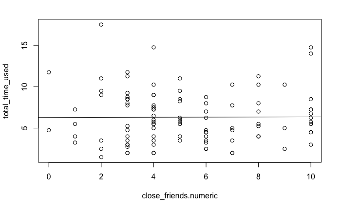

```r
close_friends <- as.character(Onderzoek_Antwoorden$How.many.friends.do.you.consider.to.be.close.friends.)
close_friends[close_friends == "> 10"] <- "10"; close_friends.numeric <- as.numeric(close_friends)
plot(close_friends.numeric, total_time_used)
trentlijn.time.close_friends <- lm(total_time_used ~ close_friends.numeric)
abline(trentlijn.time.close_friends)
```

### We gaan de tijd besteed met de sociale platvormen vergelijken met hoeveel tijd ze besteden met hun vrienden.

```r
levels_close_friends_time <- c("< 1 hour", "1 - 2 hours", "2 - 3 hours", "3 - 4 hours", "5 - 6 hours", "> 6 hours")
close_friends_time <- factor(Onderzoek_Antwoorden$How.much.time..on.average..do.you.spend.with.your.close.friends.when.you.meet., levels = levels_close_friends_time, ordered = TRUE)
close_friends_time.numeric <- c(0.5, 1.5, 2.5, 3.5, 5.5, 6.5)[close_friends_time]
close_friends_time.numeric
```

```
  [1] 5.5 2.5 6.5 1.5 1.5 3.5 3.5 6.5 5.5 5.5 3.5 6.5 5.5 5.5 3.5 5.5 3.5 2.5 6.5 1.5 3.5 6.5 3.5 5.5 3.5 3.5
 [27] 6.5 2.5 3.5 3.5 3.5 5.5 3.5 3.5 3.5 3.5 5.5 3.5 2.5 2.5 3.5 2.5 5.5 3.5 3.5 1.5 5.5 3.5 3.5 2.5 0.5 5.5
 [53] 1.5 6.5 3.5 3.5 3.5 1.5 3.5 1.5 2.5 3.5 2.5 2.5 5.5 3.5 3.5 2.5 6.5 5.5 3.5 3.5 3.5 2.5 6.5 3.5 5.5 5.5
 [79] 5.5 3.5 1.5 3.5 5.5 3.5 3.5 5.5 5.5 2.5 3.5 6.5 5.5 5.5 3.5 3.5 3.5 5.5 0.5 3.5 2.5 5.5 3.5 5.5 1.5 5.5
[105] 1.5
```

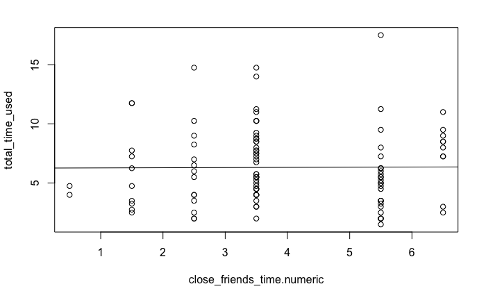

```r
plot(close_friends_time.numeric, total_time_used)
trentlijn.time.close_friends_time <- lm(total_time_used ~ close_friends_time.numeric)
abline(trentlijn.time.close_friends_time)
```

### Tijd besteed met vrienden vergelijken tegen hoeveel vrienden ze hebben

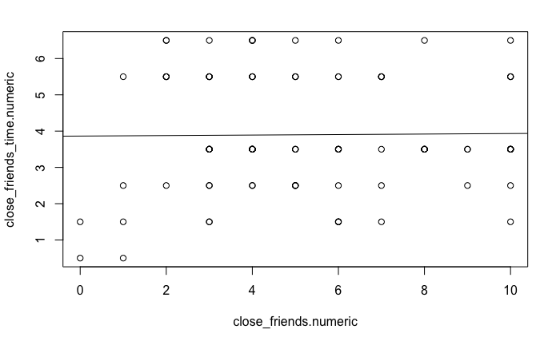

```r
plot(close_friends_time.numeric ~ close_friends.numeric)
trentlijn.close_friends.close_friends_time <- lm(close_friends_time.numeric ~ close_friends.numeric)
abline(trentlijn.close_friends.close_friends_time)
```

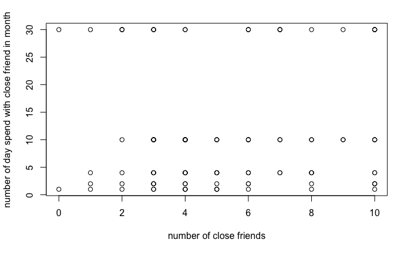

```r
#close_friends_time.numeric
close_friends_meting <- Onderzoek_Antwoorden$How.frequently..on.average..do.you.meet.your.close.friends.outside.of.social.media.
close_friends_meting.numeric <- c(30, 1, 4, 10, 2)[close_friends_meting]
plot(close_friends_meting.numeric ~ close_friends,
     xlab = "number of close friends",
     ylab = "number of day spend with close friend in month")
```

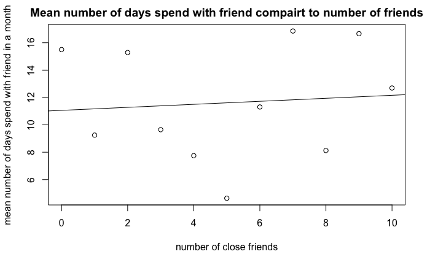

```r
close_friends_meting.list <- vector("list", 10)
for (num in 0:10){
  close_friends_meting.list[[num+1]]<- close_friends_meting.numeric[close_friends == num]
}
close_friends_meting.mean <- lapply(close_friends_meting.list, mean)
plot(unlist(close_friends_meting.mean) ~ seq(0, 10),
     main = "Mean number of days spend with friend compairt to number of friends",
     xlab = "number of close friends",
     ylab = "mean number of days spend with friend in a month"
     )
abline(lm(unlist(close_friends_meting.mean) ~ seq(0, 10)))
```

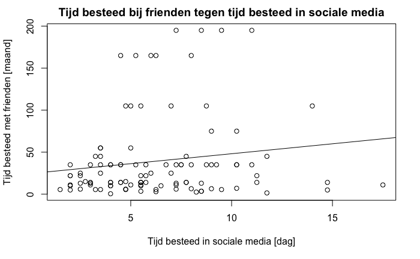

```r
time_spend_with_friends.month <- close_friends_time.numeric * close_friends_meting.numeric
plot(time_spend_with_friends.month ~ total_time_used,
     main = "Tijd besteed bij frienden tegen tijd besteed in sociale media",
     xlab = "Tijd besteed in sociale media [dag]",
     ylab = "Tijd besteed met frienden [maand]")
abline(lm(time_spend_with_friends.month ~ total_time_used))
```